# Percepciones de que el esfuerzo y el talento son recompensados

Socialización escolar y contexto en estudiantes de Chile (EDUMER)

Nicolás Outerbridge

# Relevancia

## De las reformas educativas de la dictadura a la socialización meritocrática

- **Reformas en dictadura (1973-1990):** se aplicaron a la educación y la organizaron como un **cuasi-mercado**, con subvención a la demanda y competencia entre escuelas por la matrícula (Verger et al. 2016).
- **1. Las familias eligen y responden:** al ser un mercado, cada familia o individuo es responsable de la educación a la que accede, y su trayectoria se lee como **producto de su esfuerzo** (Canales Cerón et al. 2022).
- **2. Las escuelas compiten por el rendimiento:** buscan atraer a estudiantes académicamente capaces, y el SIMCE publicado y la selección vuelven el resultado medible (Verger et al. 2016; Contreras et al. 2010).
- **3. El mérito se hace visible:** notas y pruebas muestran quién tiene éxito, y éxito y fracaso se atribuyen al esfuerzo y la capacidad individuales (Rohde 2023; Wiederkehr et al. 2015).
- **¿Por qué en Chile especialmente?** El cuasi-mercado se aplicó **antes, por más tiempo y a mayor escala** que en otros países (Verger et al. 2016), y desde los ochenta la sociedad enfatiza el mérito (Palet et al. 2017).

## Cómo la escuela enseña que el mérito explica el resultado

- **Internalidad**: éxitos y fracasos escolares se explican por el esfuerzo y la capacidad individuales (Wiederkehr et al. 2015; Darnon et al. 2018).
- **Cuantificación del mérito**: notas y diplomas hacen parecer que el estatus es merecido (Rohde 2023).
- **Recontextualización ideológica**: el origen social se transforma en diferencia individual (Bourdieu).
- Si el estudiante aprende en la escuela que el esfuerzo y el talento se recompensan, esa lectura puede **transferirse** a cómo interpreta la sociedad.

## Por qué importa percibir que el esfuerzo se recompensa

- Es una forma de **legitimar la desigualdad**: presenta la distribución desigual como resultado del mérito individual (Castillo et al. 2019; Mijs 2018).
- Creer en la meritocracia reduce la **percepción de injusticia** de la desigualdad social (Batruch et al. 2023).
- Esa percepción **se forma temprano, en la escuela** (Castillo et al. 2024; Wiederkehr et al. 2015).

# Antecedentes conceptuales y empíricos

## Mérito y percepciones de recompensa

- **Mérito = inteligencia + esfuerzo**, no factores adscriptivos (Young, 1958).
- La **percepción meritocrática** es la evaluación de en qué medida el esfuerzo y el talento se recompensan en la práctica (Castillo et al. 2023).
- Se distingue de la **percepción de privilegio**: en qué medida el origen familiar y otros factores adscriptivos determinan los logros.
- Esta tesis estudia la percepción de que el **esfuerzo** y el **talento** son recompensados, por separado, en la escuela y en la sociedad.

## Evidencia de transferencia desde la escuela

- **Estudiantes chilenos de 8° básico** (Castillo et al. 2024):
  - En la escuela, **96,8%** está de acuerdo con que el esfuerzo es importante para obtener buenas notas (78,6% en el caso del talento).
  - En la sociedad, **62%** cree que el esfuerzo se recompensa y **63,7%** que el talento se recompensa.
- **Francia, estudiantes de secundaria (N = 242)** (Wiederkehr et al. 2015): explicar las notas por el esfuerzo se asocia con creer en una sociedad meritocrática y justa **solo entre estudiantes de bajo nivel socioeconómico y entre mujeres**.
- **Más de 40 países (N = 88.421)** (Batruch et al. 2023): creer que la escuela es meritocrática se asocia con **menor percepción de injusticia** de la desigualdad social.

## Transferecia

- **Socialización escolar** (Wiederkehr et al. 2015): notas y evaluación inculcan la norma de internalidad. Se espera que lo que se percibe en la escuela **se transfiera** a la sociedad.
- **Legitimación del privilegio / capital cultural** (Castillo et al. 2019): los favorecidos reinterpretan sus ventajas heredadas como logro. Se espera **más** percepción con más estatus y capital cultural. En adultos, el ingreso se asocia con más percepción de meritocracia.
- **Efecto iluminador / función paliativa** (Castillo et al. 2024; Wiederkehr et al. 2015): la educación da una mirada crítica, y los desfavorecidos dependen de la creencia escolar. Se espera **menos** percepción con más estatus, y una transferencia más fuerte en bajo nivel socioeconómico. En adultos, la educación (controlando el ingreso) se asocia con menos percepción.

## Modelo conceptual

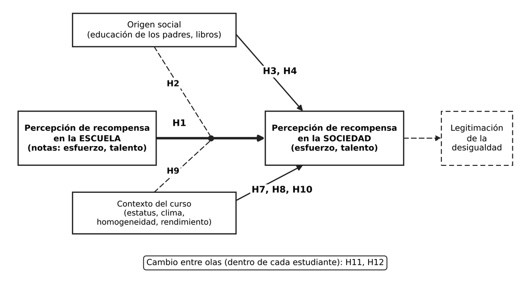

Línea continua: efecto principal. Línea punteada que llega al punto sobre H1: interacción (moderación). Recuadro punteado: consecuencia teórica, no contrastada aquí.

# Pregunta y objetivos

## Pregunta de investigación

### Pregunta

¿En qué medida la percepción de que el esfuerzo y el talento son recompensados en la escuela se transfiere a la percepción de que lo son en la sociedad, y cómo varía esa transferencia según el origen social?

### Objetivo general

Analizar la transferencia de la percepción de recompensa al esfuerzo y al talento desde la escuela a la sociedad, y su variación según factores individuales y contextuales.

## Objetivos específicos

1. **Transferencia:** estimar la asociación entre la percepción de recompensa en las notas y en la sociedad (H1).
2. **Origen social:** examinar si el estatus y el capital cultural se asocian con la percepción, y si moderan la transferencia (H2 a H4).
3. **Experiencia escolar:** analizar el rol del rendimiento, la justicia percibida y la creencia en la meritocracia escolar (H5 y H6).
4. **Contexto del curso:** evaluar los efectos contextuales y su moderación de la transferencia (H7 a H10).
5. **Cambio en el tiempo:** describir cómo cambia la percepción dentro de cada estudiante entre olas (H11 y H12).

# Hipótesis

## Hipótesis contrastadas bivariadamente

Cada hipótesis se formula para esfuerzo (a) y talento (b) por separado.

- **H1a-b:** más percepción de recompensa en las notas, **más** percepción equivalente en la sociedad (transferencia).
- **H3a-b:** la educación de los padres se asocia con la percepción de recompensa. Expectativas rivales: **positiva** (legitimación del privilegio) o **negativa** (efecto iluminador).
- **H4:** más libros en el hogar (capital cultural), **más** percepción de recompensa al **talento**.
- **H5a-b:** mayor rendimiento y justicia percibida en las notas, **más** percepción.
- **H6a-b:** mayor creencia en la meritocracia escolar, **más** percepción.

## Hipótesis para el análisis multinivel

- **H7a-b:** mayor **estatus promedio del curso**, más percepción, más allá del origen propio (efecto contextual).
- **H8a-b:** mayor **clima meritocrático** del curso, más percepción, más allá de la propia adhesión (efecto contextual).
- **H10a-b:** cursos **socioeconómicamente más homogéneos**, más percepción (efecto contextual, exploratoria).
- **H11:** la percepción de recompensa al esfuerzo **disminuye** dentro de cada estudiante entre olas (cambio intraindividual).
- **H12a-b:** mejorar el rendimiento o la justicia percibida respecto del propio promedio **aumenta** la percepción (efecto intraindividual).

## Hipótesis multinivel: interacciones (moderación)

Solo **dos** hipótesis son de interacción: plantean que el efecto de H1 **cambia según otra variable**. Ambas son exploratorias.

- **H2a-b:** percepción en las notas **×** nivel socioeconómico del estudiante. La transferencia (H1) es **más fuerte** en estudiantes de **menor** nivel socioeconómico (función paliativa).
- **H9a-b:** percepción en las notas **×** rendimiento promedio del curso. La transferencia (H1) se **atenúa** en cursos de **mayor** rendimiento promedio (efecto iluminador).

Interacción entre variables del mismo nivel (H2) y entre niveles (H9). Se contrastan con el **término producto** en los modelos mixtos.

# Metodología

## Datos y muestra

- **Panel EDUMER**: estudiantes de 6° básico a 2° medio.
- **12 establecimientos** y alrededor de **35 cursos**; el curso se identifica combinando establecimiento (`d2`) y curso (`d3_def`).
- Análisis bivariado actual con la **Ola 2** (n ≈ 670 con dato en las variables dependientes).
- Con 12 establecimientos **no se estiman efectos contextuales de escuela**; el contexto se define a nivel de **curso**, y la dependencia del establecimiento entra como control.
- Códigos 88 y 99 se tratan como datos perdidos.

## Variables

**Dependientes** (escala 1 a 4)

- Esfuerzo recompensado en Chile (`p1_1`)
- Inteligencia y habilidad recompensadas en Chile (`p1_2`)

Se analizan por separado, sin índice.

**Experiencia escolar**

- Recompensa en las notas (`p2_1`, `p2_2`)
- Creencia en la meritocracia escolar (`p2_3`)
- Promedio de notas (`p4`)
- Justicia percibida: J = ln(nota / nota merecida)

**Origen social**

- Estatus: promedio de la educación de madre y padre
- Capital cultural: libros en el hogar (`p30`)

**Contexto (curso)**

- Composición socioeconómica (media)
- Heterogeneidad socioeconómica (desviación estándar)
- Clima meritocrático (media de BSM) y rendimiento promedio

**Controles**: dependencia del establecimiento, entre otros.

## Estrategia de análisis

**1. Bivariado (Ola 2)**

- Asociación ordinal: **rho de Spearman** 95%

**2. Modelos mixtos (próxima etapa)**

- **Efectos contextuales (H7 a H10):** modelos mixtos con estudiantes anidados en cursos (intercepto aleatorio por curso). El estatus individual se centra en la media del curso para separar el efecto del contexto del origen propio.
- **Interacciones (H2 y H9):** término producto entre la percepción en las notas y el nivel socioeconómico individual (H2) o el rendimiento promedio del curso (H9, interacción entre niveles).
- **Cambio en el tiempo (H11 y H12):** modelos mixtos de medidas repetidas (olas anidadas en estudiantes), que separan la variación dentro de cada persona de la diferencia entre personas.

# Análisis bivariado

## Percepción de recompensa en la sociedad (Ola 2)

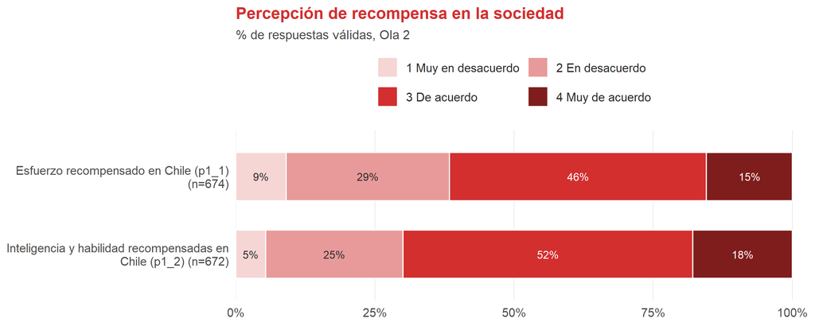

## Magnitud de las asociaciones

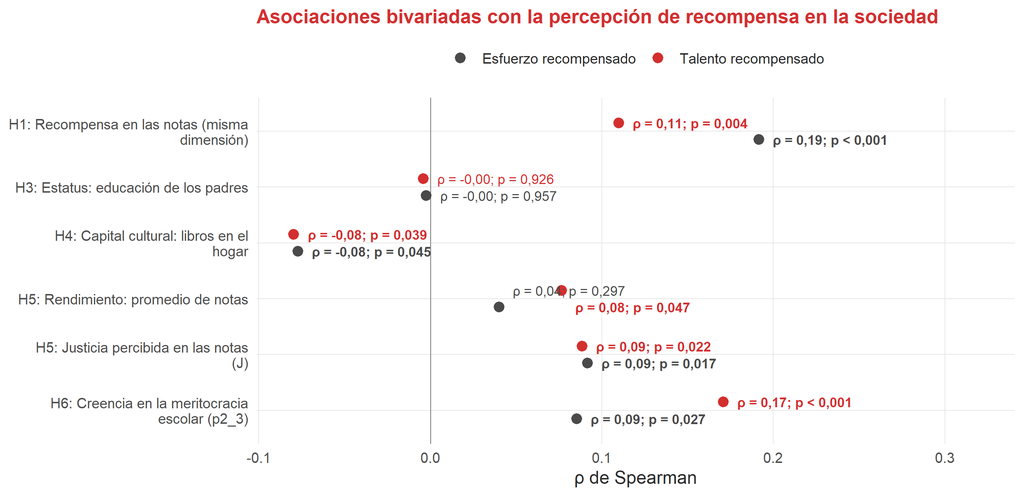

## Transferencia de las notas a la sociedad (H1)

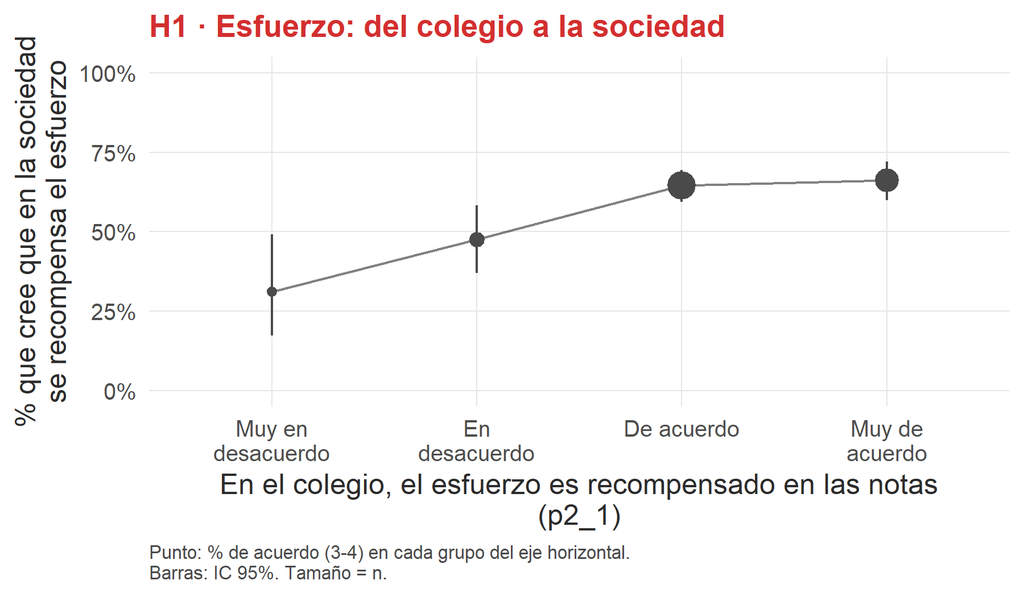

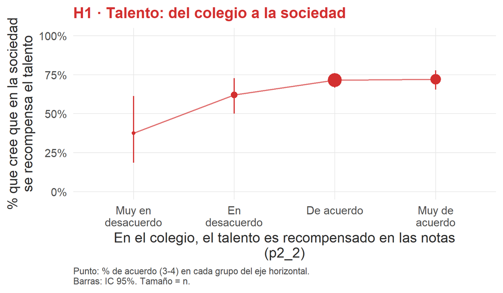

La línea sube: quienes ven más recompensa en las notas también ven más recompensa en la sociedad (de cerca de 30-37% en “Muy en desacuerdo” a cerca de 65-72% en “De acuerdo”). El salto está entre los extremos bajos y las categorías de acuerdo; entre “De acuerdo” y “Muy de acuerdo” casi no cambia. Los grupos de desacuerdo son pequeños y sus barras largas.

## Origen social (H3 y H4)

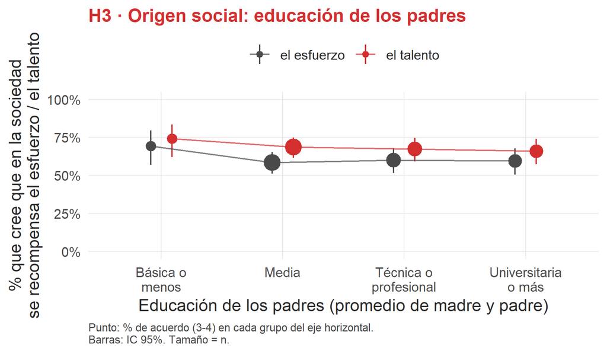

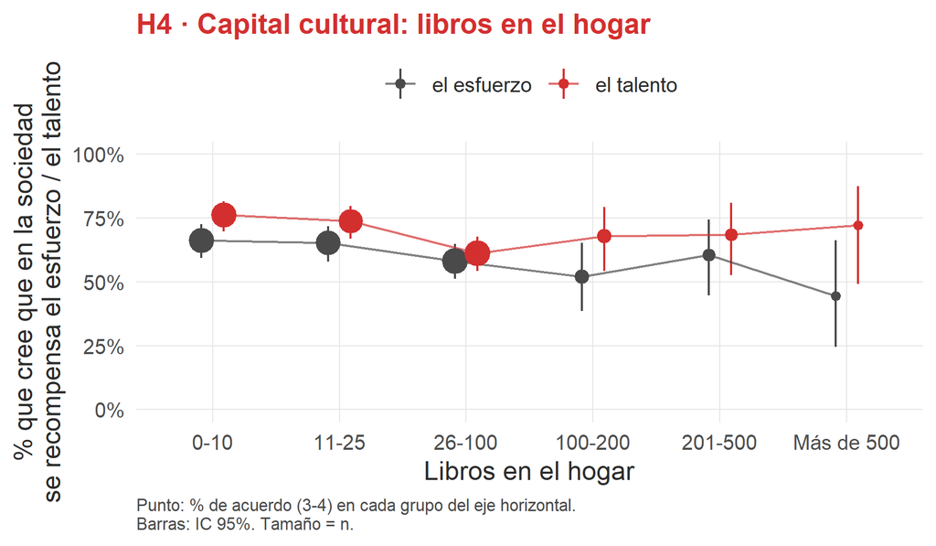

Con la educación de los padres las líneas son casi planas: el estatus no distingue la percepción de recompensa. Con los libros en el hogar, el % tiende a bajar en los grupos con más libros, lo contrario de lo esperado en H4, aunque con barras largas en las categorías pequeñas.

## Rendimiento y justicia percibida (H5)

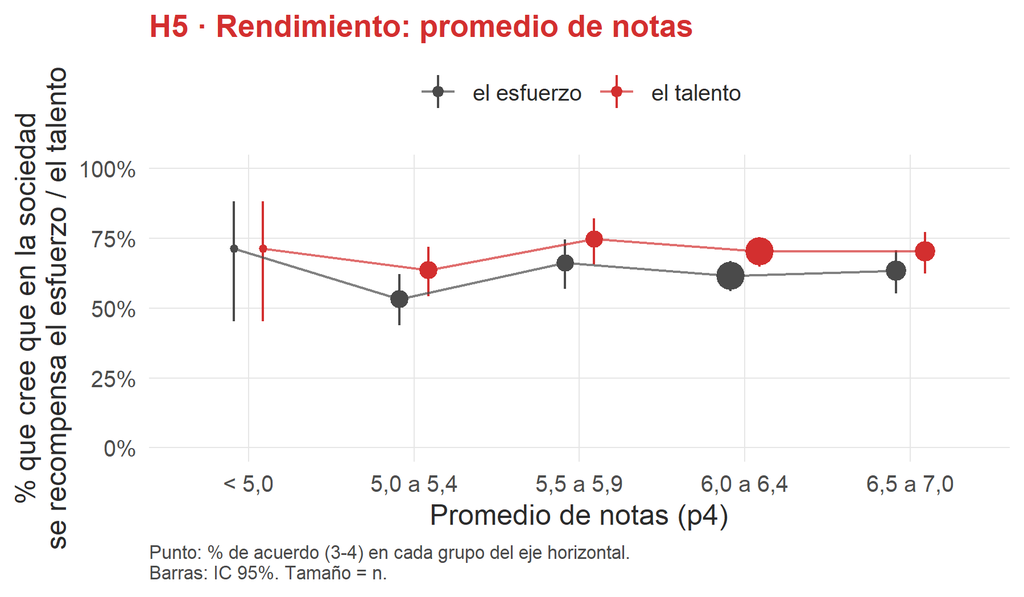

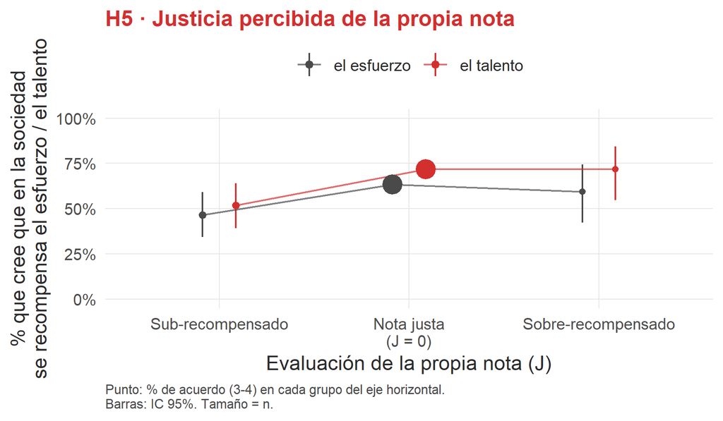

Las notas se asocian algo más con la percepción de recompensa al talento que con la del esfuerzo, con una pendiente leve. Quienes se ven sub-recompensados muestran menos acuerdo que quienes consideran justa su nota; los sobre-recompensados no se distinguen de estos últimos (barras muy largas).

## Contexto del curso (H7 y H10)

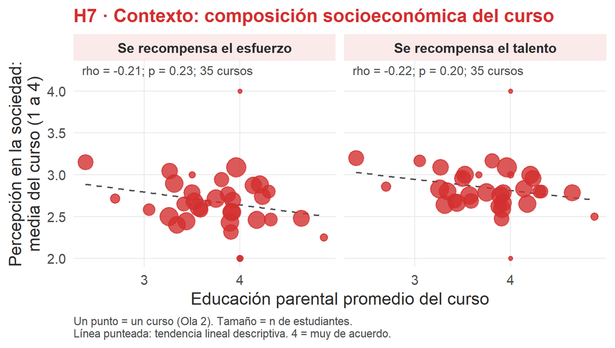

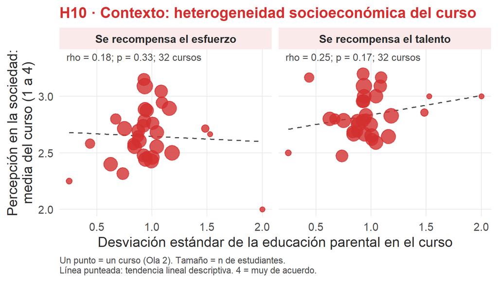

Nube de puntos sin una pendiente clara y sin asociaciones significativas: ni la composición ni la heterogeneidad socioeconómica del curso se asocian con su percepción promedio. Con pocos cursos y algunos muy pequeños, esto no descarta un efecto.

# Referencias

Batruch, Anatolia, Jolanda Jetten, Herman Van De Werfhorst, Céline Darnon, y Fabrizio Butera. 2023. «Belief in School Meritocracy and the Legitimization of Social and Income Inequality». *Social Psychological and Personality Science* 14 (5): 621-35. https://doi.org/10.1177/19485506221111017.

Canales Cerón, Manuel, Víctor Sebastián Orellana Calderón, Fabián Guajardo Mañán, Manuel Canales Cerón, Víctor Sebastián Orellana Calderón, y Fabián Guajardo Mañán. 2022. «Sujeto y cotidiano en la era neoliberal: el caso de la educación chilena». *Revista mexicana de ciencias políticas y sociales* 67 (244): 285-307. https://doi.org/10.22201/fcpys.2448492xe.2022.244.70386.

Castillo, Juan Carlos, Julio Iturra, Luis Maldonado, Jorge Atria, y Francisco Meneses. 2023. «A Multidimensional Approach for Measuring Meritocratic Beliefs: Advantages, Limitations and Alternatives to the ISSP Social Inequality Survey». *International Journal of Sociology* 53 (6): 448-72. https://doi.org/10.1080/00207659.2023.2274712.

Castillo, Juan Carlos, Mauricio Salgado, Kevin Carrasco, y Andreas Laffert. 2024. «The Socialization of Meritocracy and Market Justice Preferences at School». *Societies* 14 (11): 214. https://doi.org/10.3390/soc14110214.

Castillo, Juan C., Alex Torres, Jorge Atria, y Luis Maldonado. 2019. «Meritocracia y Desigualdad Económica: Percepciones, Preferencias e Implicancias». *Revista Internacional de Sociología* 77 (1): e117. https://doi.org/10.3989/ris.2019.77.1.17.114.

Contreras, Dante, Paulina Sepúlveda, y Sebastián Bustos. 2010. «When Schools Are the Ones That Choose: The Effects of Screening in Chile*». *Social Science Quarterly* 91 (5): 1349-68. https://doi.org/10.1111/j.1540-6237.2010.00735.x.

Darnon, Céline, Virginie Wiederkehr, Benoît Dompnier, y Delphine Martinot. 2018. «“Where There Is a Will, There Is a Way”: Belief in School Meritocracy and the Social-Class Achievement Gap». *British Journal of Social Psychology* 57 (1): 250-62. https://doi.org/10.1111/bjso.12214.

Mijs, Jonathan J B. 2018. *The Unfulfillable Promise of Meritocracy: Three Lessons and Their Implications for Justice in Education*. 6w9rg_v1. SocArXiv. https://doi.org/10.1007/s11211-014-0228-0.

Palet, Andrea, Pilar de Aguirre, y PNUD Chile, eds. 2017. *Desiguales: orígenes, cambios y desafíos de la brecha social en Chile*. PNUD : Uqbar Editores.

Rohde, Noëlle. 2023. «“To Assign People Their Place in Society”: School Grades and the Quantification of Merit». *Economy and Society* 52 (3): 506-30. https://doi.org/10.1080/03085147.2023.2225346.

Verger, Antoni, Xavier Bonal, y Adrián Zancajo. 2016. «Recontextualización de Políticas y (Cuasi)Mercados Educativos. Un Análisis de Las Dinámicas de Demanda y Oferta Escolar En Chile». *Education Policy Analysis Archives* 24 (febrero): 27. https://doi.org/10.14507/epaa.24.2098.

Wiederkehr, Virginie, Virginie Bonnot, Silvia Krauth-Gruber, y Céline Darnon. 2015. «Belief in School Meritocracy as a System-Justifying Tool for Low Status Students». *Frontiers in Psychology* 6 (julio). https://doi.org/10.3389/fpsyg.2015.01053.